# making-the-most-of-node-essentials

# How to make most of Node Essentials

Every game project is unique and requires different nodes and features. Once you learned the foundations, you face a massive amount of features, without really knowing when to use which.

With over 100 nodes and 3000 functions, exploring Godot’s nodes takes *insane* amounts of time: we’ve been at it for years, and we still discover new tricks with every project.

[figure not shown]

That’s why we created a **curated cookbook**.

## A curated cookbook

Node Essentials is not a collection of step-by-step tutorials for beginners.

Instead, it’s a collection of guides that quickly give developers many examples of using nodes to create a given game mechanic or feature. You can read the guides and play demos in any order and come back to them anytime.

For every node, we give you its most important features and the most useful ways you can use it in practice.

We are not trying to be exhaustive: our goal is to **save you as much time as possible** by teaching you the features that will be most useful to **you**.

## Learn fast with the interactive demos and cheatsheet

Node Essentials comes with two key tools to explore the most useful Godot features available to you:

1. The Godot project lets you play every demo quickly with its convenient navigation.
2. The downloadable cheatsheet helps you find the nodes you need with its simple overview cards.

To access those, you need to download the course files. The downloads come with all node guides, the cheatsheet, Godot project, and the entire MIT-licensed source code. Everything’s DRM-free and yours to keep.

You can download the course files as two .zip files on this page, where you’ll find detailed instructions: How to download the course files

## Learn to use the cheatsheet

In this video, you’ll see how the cheatsheet works and how to make the most of it.

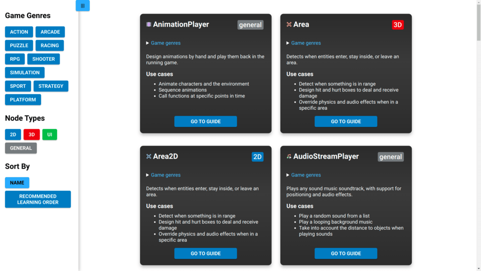

In summary, the cheatsheet contains:

Note the cheatsheet will evolve with future releases. We’ll extend and improve it as we work on more nodes.

## Learn to use the Godot demos

In this video, we focus on the Godot demos and cover how to navigate them and explore the source code.

[figure not shown]

## How to ask questions

Your questions and feedback are very much welcome.

You can ask questions at the bottom of every guide on the Mavenseed website. We wrote a short guide to do so: How to ask questions.